# INFSCI 2595 Final Project

Part 2D2, Regression - Resampling - ENET

Zhenyu Li

2022-04-20

```r
library(tidyverse)
theme_set(theme_linedraw())
library(tidymodels)
tidymodels_prefer()
source("./scripts/utils.R")
```

```r
df <- readr::read_csv("./data/final_project_train.csv", col_names = TRUE)
df_regr <- df %>% select(-c(rowid,outcome)) %>% mutate(response = log(response))
```

## Elastic Net

Use Elastic Net to provide regularization to the two complex models that resulted extreme poor performances during the resampling.

### Models

**Define the linear models to tune with Elastic Net.**

**The preprocessing steps**

```r
bp_prep <- recipe(response ~ ., data=df_regr) %>%
  step_normalize(all_numeric_predictors())
  # prep(training=df_regr, retain=T) %>% bake(new_data=NULL)
```

**`mod_2D2`: All pairwise interactions of continuous inputs, include additive categorical features.**

```r
bp_2D2 <- bp_prep %>%
  step_interact(~ all_numeric_predictors():all_numeric_predictors(), sep = ":") %>%
  step_dummy(all_nominal_predictors())
```

**`mod_2D5_2Ac4`: All pairwise interactions for all input variables.**

```r
bp_2D5_2Ac4 <- bp_prep %>%
  step_interact(~ all_numeric_predictors():all_numeric_predictors(), sep=":") %>%
  step_dummy(all_nominal_predictors()) %>%
  step_interact(~ starts_with("region"):matches("^x.{1}_\\d+$"), sep=":") %>%
  step_interact(~ starts_with("customer"):matches("^x.{1}_\\d+$"), sep=":") %>%
  step_interact(~ matches("^region_.{2}$"):matches("^customer_.{1,6}$"), sep=":")
```

## Tuning

### Explore

**First use Lasso to explore the range for parameter tuning.**

**Define the Lasso only model specification.**

```r
lasso_explore_spec <-
  linear_reg(penalty = 0.1, mixture = 1) %>%
  set_engine("glmnet", intercept = TRUE)
```

**Fit both models with Lasso.**

```r
lasso_fit_2D2 <- workflow() %>%
  add_model(lasso_explore_spec) %>%
  add_recipe(bp_2D2) %>%
  fit(df_regr)

lasso_fit_2D5 <- workflow() %>%
  add_model(lasso_explore_spec) %>%
  add_recipe(bp_2D5_2Ac4) %>%
  fit(df_regr)
```

**Generate the coefficient paths.**

[figure not shown]

```r
lasso_fit_2D2 %>% extract_fit_parsnip() %>%
  pluck('fit') %>%
  plot(xvar = 'lambda')
```

[figure not shown]

```r
lasso_fit_2D5 %>% extract_fit_parsnip() %>%
  pluck('fit') %>%
  plot(xvar = 'lambda')
```

### Setup

**Create the custom search grid for the penalty strength and mixing fraction parameters.**

- Use the bound of penalty strength for the range of parameters I am interested to tune.
- Use 0.1 as lower bound for mixing fraction to avoid fully Ridge.

```r
# set tuning parameter ranges
my_lambda <- penalty(range = c(-6,-1), trans = log_trans())
my_alpha <- mixture(range = c(0.1, 1.0))
# construct the tuning grid
enet_grid <- grid_regular(
  my_lambda, my_alpha,
  levels = c(penalty = 80, mixture = 5))
```

**Define the resampling scheme**

- Use the 5-fold cross-validation with 5 repeats.
- Model specification: use `glmnet` engine.

```r
set.seed(1324)
cv_folds <- vfold_cv(df_regr, v = 5, repeats = 5)
my_metrics <- metric_set(rmse, mae, rsq)
```

**Create workflow set.**

```r
enet_spec <-
  linear_reg(penalty = tune(), mixture = tune()) %>%
  set_engine("glmnet", intercept = TRUE, standardize = TRUE)

enet_wset <-
  workflow_set(
    preproc = list(
      all_cont_pairwise = bp_2D2,
      all_pairwise = bp_2D5_2Ac4
      ),
    models = list(enet = enet_spec)
  )
```

### Execute

Note: to speed up knit, these two code blocks are set `eval=FALSE`. They can be manually executed in the rmarkdown file.

```r
# create cluster to allow parallel computing
if (parallel::detectCores(logical=FALSE) > 3) {
  library(doParallel)
  num_cores <- parallel::detectCores(logical=FALSE)
  cl <- makePSOCKcluster(num_cores - 2)
  registerDoParallel(cl)
}
# start tuning
tune_2D_enet <- enet_wset %>%
  workflow_map(
    fn = "tune_grid",
    grid = enet_grid,
    resamples = cv_folds,
    metrics = my_metrics,
    control = control_grid(
      # save_pred = TRUE,
      parallel_over = "everything",
      save_workflow = TRUE
    ),
    verbose = T
  )
# close the cluster
stopCluster(cl)
```

```r
readr::write_rds(tune_2D_enet,"./models/tune_2D_enet")
```

## Conclusions

```r
tune_2D_enet <- readr::read_rds("./models/tune_2D_enet")
names(tune_2D_enet$result) <- tune_2D_enet$wflow_id
```

### Performance

**Visualize the model performance metrics across the two models tuned.**

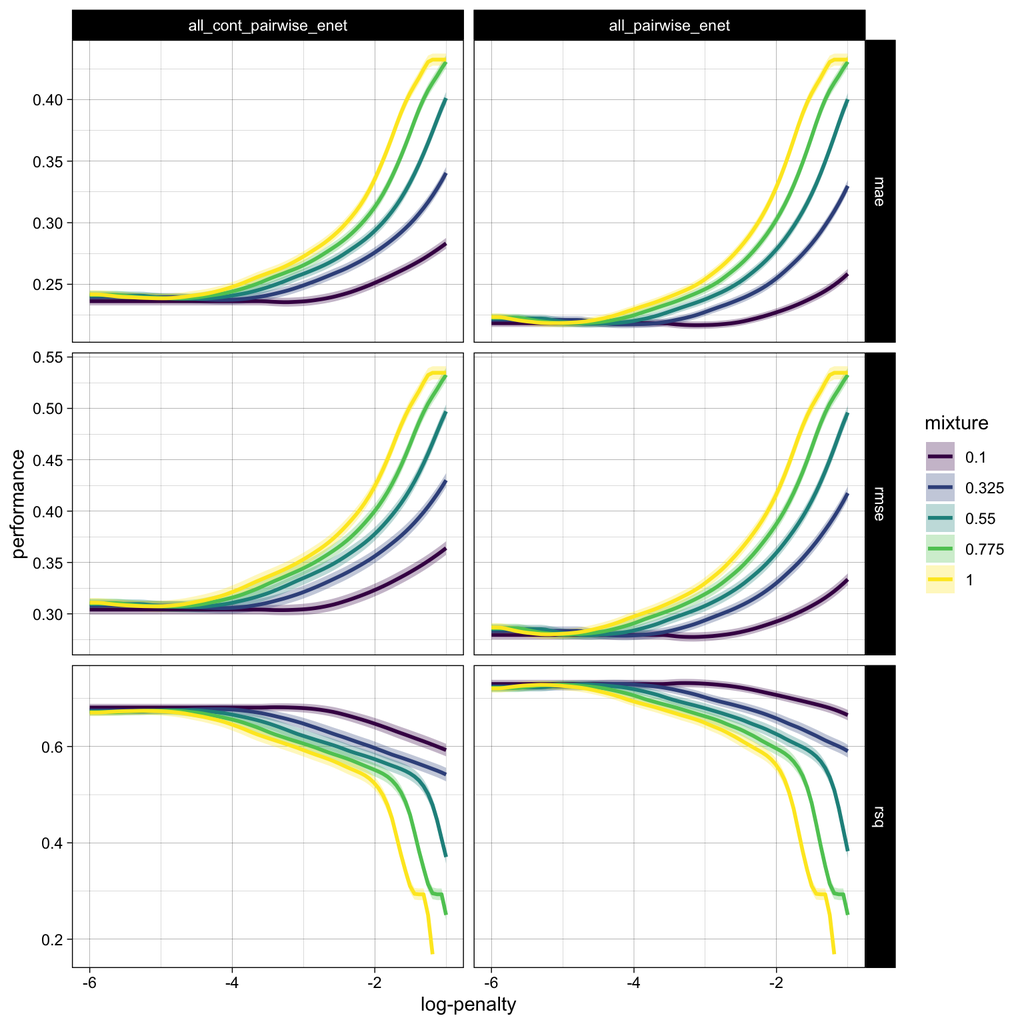

```r
tune_2D_enet$result %>%
  map_dfr(collect_metrics, .id="wflow_id") %>%
  ggplot(aes(x = log(penalty))) +
  geom_ribbon(
    aes(ymin = mean - std_err, ymax = mean + std_err,
        group = interaction(mixture, .metric),
        fill = as.factor(mixture)),
    alpha = 0.3) +
  geom_line(
    aes(y = mean,
        group = interaction(mixture, .metric),
        color = as.factor(mixture)),
    size = 1) +
  facet_grid(.metric ~ wflow_id, scales = "free_y") +
  xlab("log-penalty") + ylab("performance") + labs(color="mixture", fill="mixture") +
  scale_color_viridis_d() + scale_fill_viridis_d()
```

- Elastic Net prefers Ridge over Lasso (small mixture fraction). This is as expected because some inputs are correlated, which can make Lasso struggle.
- The model performances from “all pairwise interactions” (right side grids) have overall better performances compared to the “continuous pairwise interactions” (left side grids).
- Judging from MAE (top grid row) the best log-penalty is at about -3.

### Best Model

**Select the best tuning parameters for each model based on RMSE.**

```r
enet_best_rmse_params <-
  tune_2D_enet$result %>%
  map_dfr(select_by_pct_loss, desc(mixture), metric = 'rmse', .id = "wflow_id")
enet_best_rmse_params %>% select(-starts_with("."))
```

```
## # A tibble: 2 × 6
##   wflow_id               penalty mixture  mean     n std_err
##   <chr>                    <dbl>   <dbl> <dbl> <int>   <dbl>
## 1 all_cont_pairwise_enet  0.0121   0.775 0.310    25 0.00568
## 2 all_pairwise_enet       0.0121   0.775 0.283    25 0.00459
```

**Visualize all three performance metrics for the best models.**

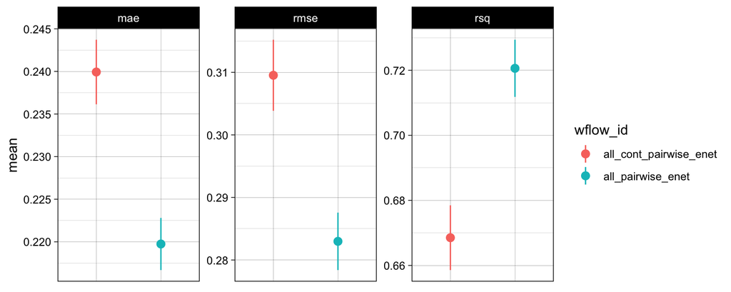

```r
tune_2D_enet %>% collect_metrics() %>%
  inner_join(enet_best_rmse_params %>% select(wflow_id, .config), by = c("wflow_id", ".config")) %>%
  ggplot(aes(color = wflow_id, x = wflow_id)) +
  geom_pointrange(aes(y=mean, ymax=mean+std_err, ymin=mean-std_err)) +
  facet_wrap(~ .metric, scales = "free_y") +
  theme(axis.text.x = element_blank(), axis.ticks.x = element_blank()) +
  xlab(label = NULL)
```

- The “all pairwise interactions” one is the clear winner as it has lower RMSE/MAE and higher R-Squared than the other model.

**Fit both best models and examine the number of non-zero coefficients.**

```r
enet_wset %>%
  extract_workflow("all_cont_pairwise_enet") %>%
  finalize_workflow(parameters = enet_best_rmse_params %>% slice(1)) %>%
  fit(df_regr) %>%
  tidy() %>% filter(estimate != 0) %>% nrow()
```

```
## [1] 72
```

```r
enet_wset %>%
    extract_workflow("all_pairwise_enet") %>%
    finalize_workflow(parameters = enet_best_rmse_params %>% slice(2)) %>%
  fit(df_regr) %>%
  tidy() %>% filter(estimate != 0) %>% nrow()
```

```
## [1] 113
```

**Finalize the workflow for the best model and retrain with resampling to save predictions.**

```r
enet_best_wflow_mae <- "all_pairwise_enet"
enet_best_param <- enet_best_rmse_params %>%
      filter(wflow_id==enet_best_wflow_mae) %>%
      select(all_of(names(enet_grid)))

mod_2D_enet_best_wflow <-
  enet_wset %>%
  extract_workflow(enet_best_wflow_mae) %>%
  finalize_workflow(parameters = enet_best_param)
mod_2D_enet_best_wflow$param <- enet_best_param

mod_2D_enet_best_resample <-
  mod_2D_enet_best_wflow %>%
  fit_resamples(
    resamples = cv_folds,
    metrics = my_metrics,
    control = control_resamples(save_pred = T)
  )

mod_2D_enet_best_resample %>% collect_metrics() %>% select(-.config, -.estimator)
```

```
## # A tibble: 3 × 4
##   .metric  mean     n std_err
##   <chr>   <dbl> <int>   <dbl>
## 1 mae     0.220    25 0.00306
## 2 rmse    0.283    25 0.00459
## 3 rsq     0.721    25 0.00879
```

```r
save_models(mget(ls(pattern = "^mod_2D_enet")))
```